# Prosper Loan Data

Noah Zheng

January 9, 2019

# Prosper Loan Project

## Background Information

The dataset is from Prosper, an American company in the peer-to-peer lending industry. Prosper maintains a full public database of all loans issued through its marketplace on its website. This database and all market statistics can be accessed and queried for analysis of loan performance over time.

## Source

1. https://en.wikipedia.org/wiki/Prosper_Marketplace#cite_note-Prosper_Marketplace,_Inc-6
2. https://docs.google.com/spreadsheets/d/1gDyi_L4UvIrLTEC6Wri5nbaMmkGmLQBk-Yx3z0XDEtI/edit#gid=0
3. https://www.wikihow.com/Invest-on-Prosper.com

## Process

1. Overview of the data
2. Analysis
- Univariateanalysis and plots
- Bivariate analysis and plots
- Multivariate analysis and plots
3. Final plots and summary
4. reflection

## Overview of the Data

From Udacity:

*This data set contains 113,937 loans with 81 variables on each loan, including loan amount, borrower rate (or interest rate), current loan status, borrower income, borrower employment status, borrower credit history, and the latest payment information.*

### Main Features of Interest

- ListingCreationDate
- Term
- LoanStatus
- BorrowerRate
- LeanderYield
- ProsperRating(numeric)
- ProsperScore
- ListingCategory
- BorrowerState
- IsBorrowerHomeowner
- DebtToIncomeRatio
- LoanOriginalAmount
- Investors

## Exploratory Analysis

### Univariate analysis

#### The Structure of the Data

```
## 'data.frame':    113937 obs. of  13 variables:
##  $ ListingCreationDate      : Factor w/ 113064 levels "2005-11-09 20:44:28.847000000",..: 14184 111894 6429 64760 85967 100310 72556 74019 97834 97834 ...
##  $ Term                     : int  36 36 36 36 36 60 36 36 36 36 ...
##  $ LoanStatus               : Factor w/ 12 levels "Cancelled","Chargedoff",..: 3 4 3 4 4 4 4 4 4 4 ...
##  $ BorrowerRate             : num  0.158 0.092 0.275 0.0974 0.2085 ...
##  $ LenderYield              : num  0.138 0.082 0.24 0.0874 0.1985 ...
##  $ ProsperRating..numeric.  : int  NA 6 NA 6 3 5 2 4 7 7 ...
##  $ ProsperScore             : num  NA 7 NA 9 4 10 2 4 9 11 ...
##  $ ListingCategory..numeric.: int  0 2 0 16 2 1 1 2 7 7 ...
##  $ BorrowerState            : Factor w/ 52 levels "","AK","AL","AR",..: 7 7 12 12 25 34 18 6 16 16 ...
##  $ IsBorrowerHomeowner      : Factor w/ 2 levels "False","True": 2 1 1 2 2 2 1 1 2 2 ...
##  $ DebtToIncomeRatio        : num  0.17 0.18 0.06 0.15 0.26 0.36 0.27 0.24 0.25 0.25 ...
##  $ LoanOriginalAmount       : int  9425 10000 3001 10000 15000 15000 3000 10000 10000 10000 ...
##  $ Investors                : int  258 1 41 158 20 1 1 1 1 1 ...
```

```
##                     ListingCreationDate      Term
##  2013-10-02 17:20:16.550000000:     6   Min.   :12.00
##  2013-08-28 20:31:41.107000000:     4   1st Qu.:36.00
##  2013-09-08 09:27:44.853000000:     4   Median :36.00
##  2013-12-06 05:43:13.830000000:     4   Mean   :40.83
##  2013-12-06 11:44:58.283000000:     4   3rd Qu.:36.00
##  2013-08-21 07:25:22.360000000:     3   Max.   :60.00
##  (Other)                      :113912
##                  LoanStatus     BorrowerRate     LenderYield
##  Current              :56576   Min.   :0.0000   Min.   :-0.0100
##  Completed            :38074   1st Qu.:0.1340   1st Qu.: 0.1242
##  Chargedoff           :11992   Median :0.1840   Median : 0.1730
##  Defaulted            : 5018   Mean   :0.1928   Mean   : 0.1827
##  Past Due (1-15 days) :  806   3rd Qu.:0.2500   3rd Qu.: 0.2400
##  Past Due (31-60 days):  363   Max.   :0.4975   Max.   : 0.4925
##  (Other)              : 1108
##  ProsperRating..numeric.  ProsperScore   ListingCategory..numeric.
##  Min.   :1.000           Min.   : 1.00   Min.   : 0.000
##  1st Qu.:3.000           1st Qu.: 4.00   1st Qu.: 1.000
##  Median :4.000           Median : 6.00   Median : 1.000
##  Mean   :4.072           Mean   : 5.95   Mean   : 2.774
##  3rd Qu.:5.000           3rd Qu.: 8.00   3rd Qu.: 3.000
##  Max.   :7.000           Max.   :11.00   Max.   :20.000
##  NA's   :29084           NA's   :29084
##  BorrowerState   IsBorrowerHomeowner DebtToIncomeRatio LoanOriginalAmount
##  CA     :14717   False:56459         Min.   : 0.000    Min.   : 1000
##  TX     : 6842   True :57478         1st Qu.: 0.140    1st Qu.: 4000
##  NY     : 6729                       Median : 0.220    Median : 6500
##  FL     : 6720                       Mean   : 0.276    Mean   : 8337
##  IL     : 5921                       3rd Qu.: 0.320    3rd Qu.:12000
##         : 5515                       Max.   :10.010    Max.   :35000
##  (Other):67493                       NA's   :8554
##    Investors
##  Min.   :   1.00
##  1st Qu.:   2.00
##  Median :  44.00
##  Mean   :  80.48
##  3rd Qu.: 115.00
##  Max.   :1189.00
##
```

Firtly, I am interested in the listing over the time. Therefore, I generate the following plot.

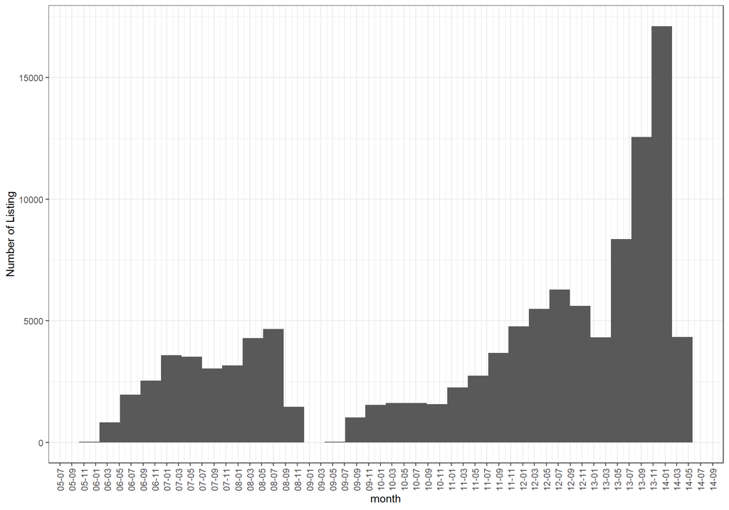

It can be noticed that there is a big drop in listing from 2008-09. It takes almost 3 years for the listing to recover to 2008-07 level. What happened in September of 2008 relating to finance is the collapse of Lehman Brothers on September 15. Another information is of interest is that the Prosper rating is introduced in July 2009, when the listing starts to increase. Another sharp decline happened in 2014-03. It can be explored further with other information.

#### The Term of Loans

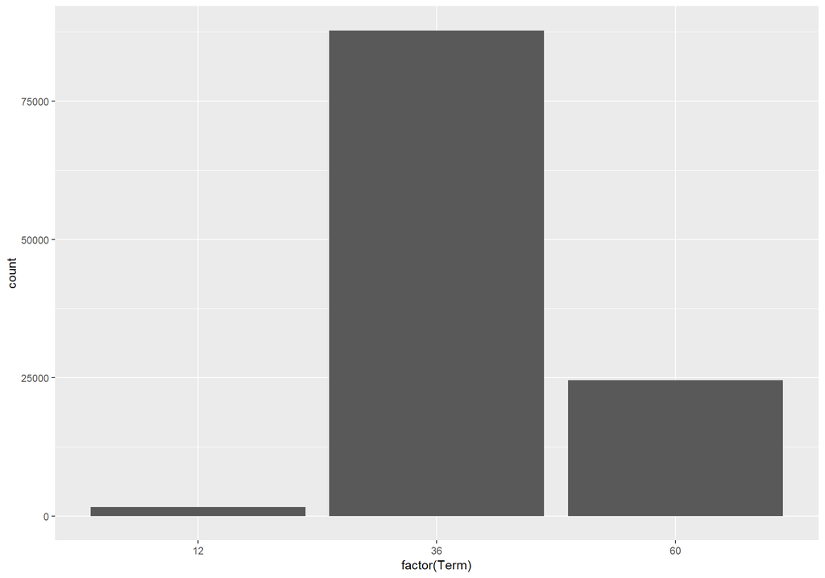

The majority of loans are with a term of 36 months. Loans with 12 months are quite small. Around 25000 loans are with a 60 months term.

#### Loan Status

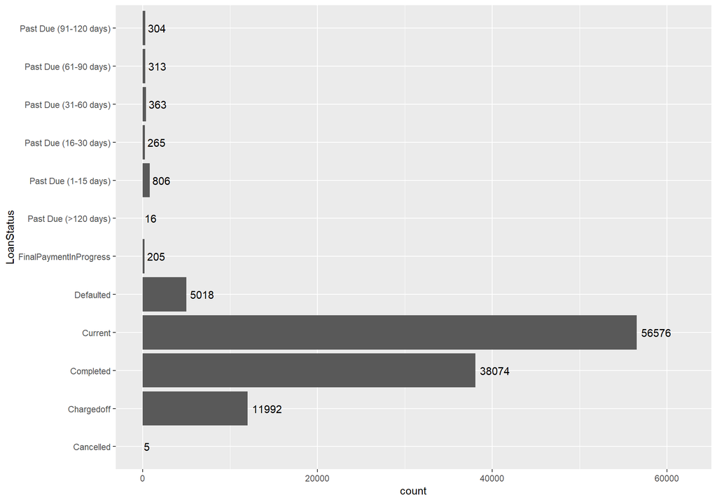

The majority of loans are current. The second is completed. The third is charged off. The fourth is defaulted.

#### The Borrower Rate

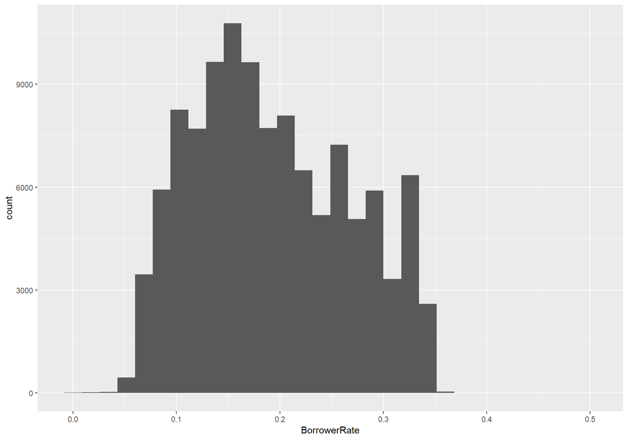

The distribution of borrower rate is right skewed with median 0.1840 < mean 0.1928.

```
##    Min. 1st Qu.  Median    Mean 3rd Qu.    Max.
##  0.0000  0.1340  0.1840  0.1928  0.2500  0.4975
```

#### Lender Yield

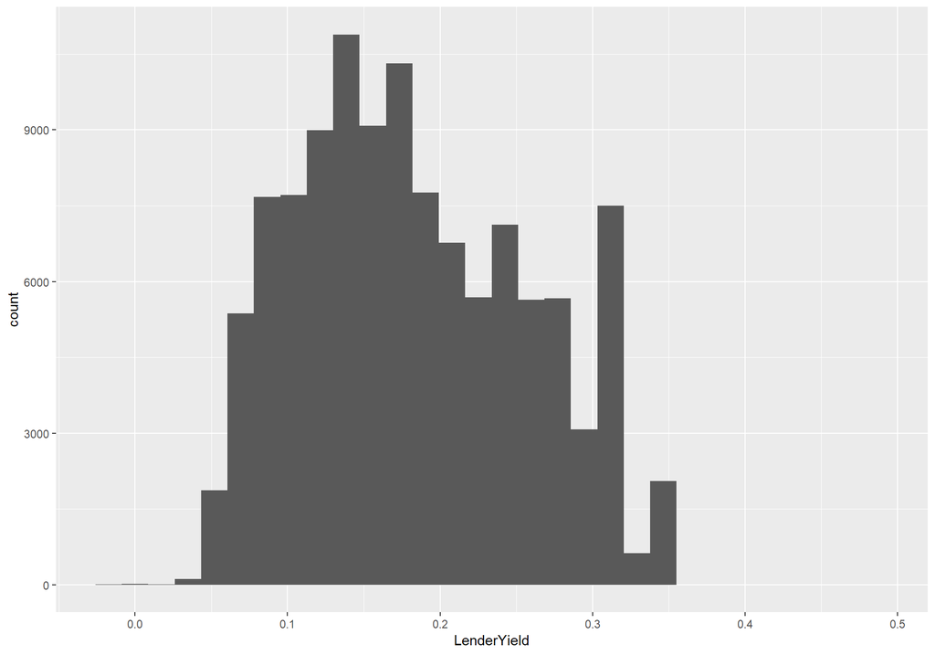

As lender yield is equal to the interest rate on the loan less the servicing fee, the shape is essentially the same as borrower rate.

```
##    Min. 1st Qu.  Median    Mean 3rd Qu.    Max.
## -0.0100  0.1242  0.1730  0.1827  0.2400  0.4925
```

#### Prosper Rating

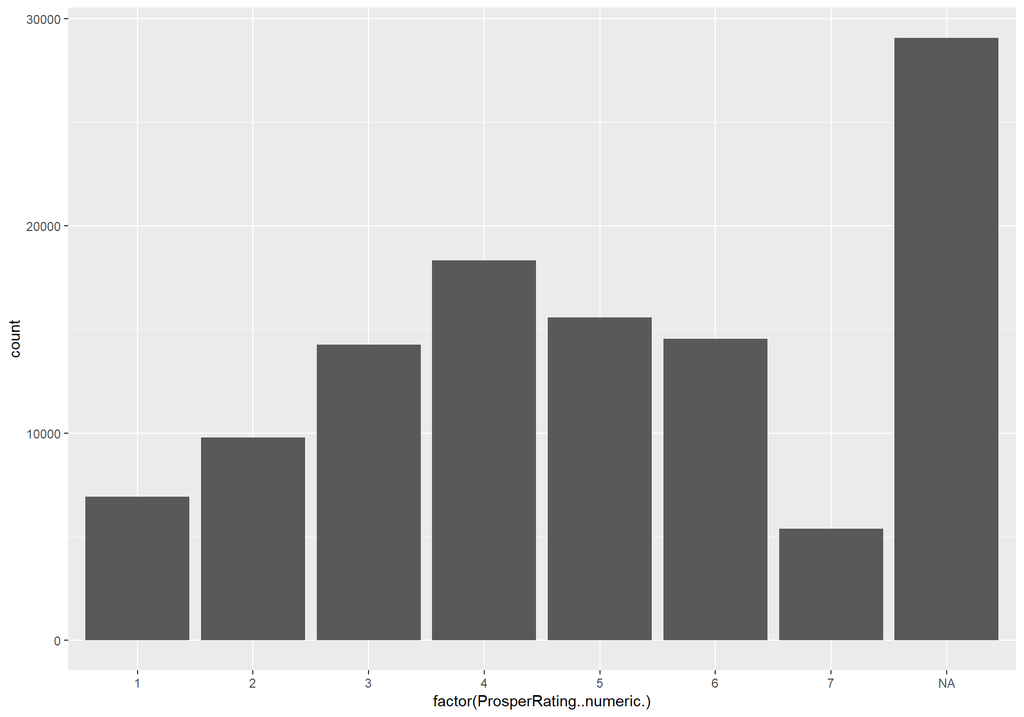

The distribution of rating is close to a normal distribution except for the NA which is because that the Prosper rating is introduced in July 2009.

#### Prosper Score

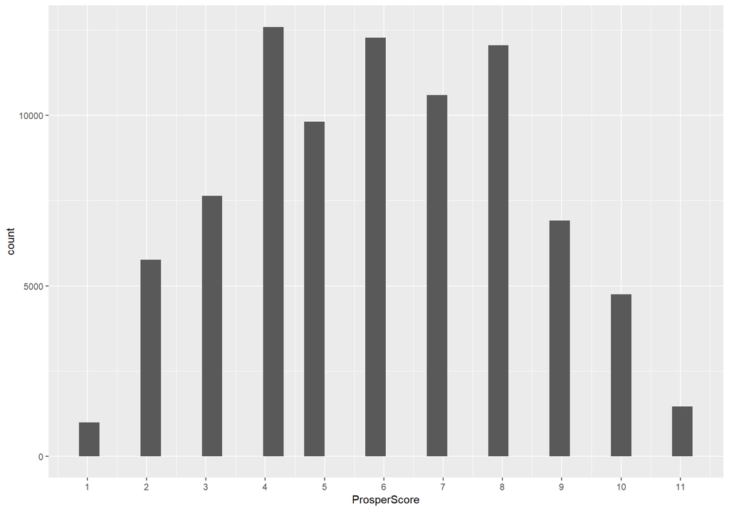

The distributinon of Prosper Score is of bell shape with a median of 6 and mean of 5.95.

```
##    Min. 1st Qu.  Median    Mean 3rd Qu.    Max.    NA's
##    1.00    4.00    6.00    5.95    8.00   11.00   29084
```

#### Listing Category

The category of the listing that the borrower selected when posting their listing: 0 - Not Available, 1 - Debt Consolidation, 2 - Home Improvement, 3 - Business, 4 - Personal Loan, 5 - Student Use, 6 - Auto, 7- Other, 8 - Baby&Adoption, 9 - Boat, 10 - Cosmetic Procedure, 11 - Engagement Ring, 12 - Green Loans, 13 - Household Expenses, 14 - Large Purchases, 15 - Medical/Dental, 16 - Motorcycle, 17 - RV, 18 - Taxes, 19 - Vacation, 20 - Wedding Loans

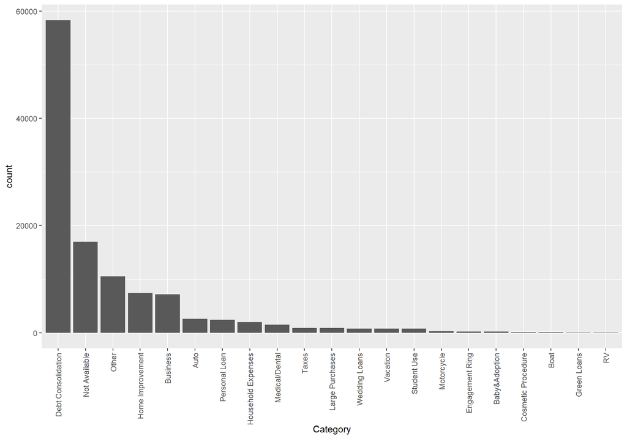

Most of the listing falls in Debt Consolidation. The second category that is useful is Home Improvement. The third is Business.

#### Borrowing State

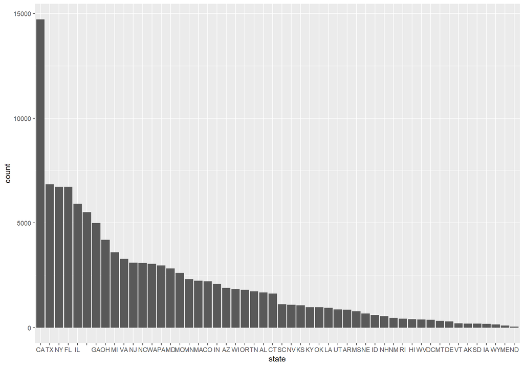

California has the most listings. The second is Texas. The third is New York.

#### Borrower a Home Owner

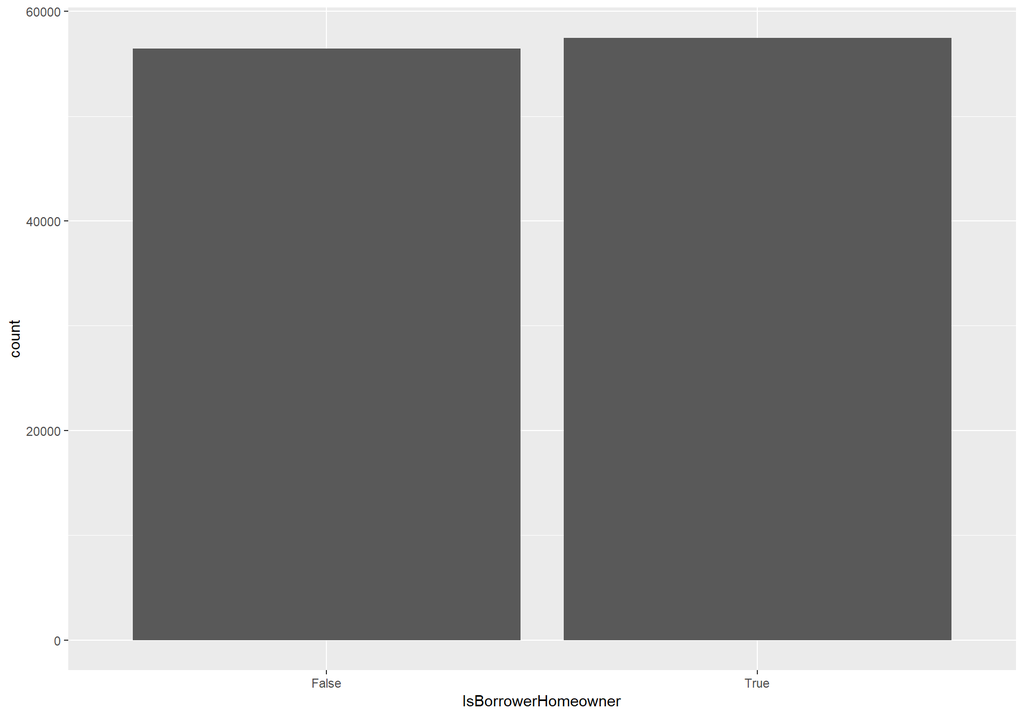

There are around 1000 more home owners.

```
## False  True
## 56459 57478
```

#### Debt to Income Ratio

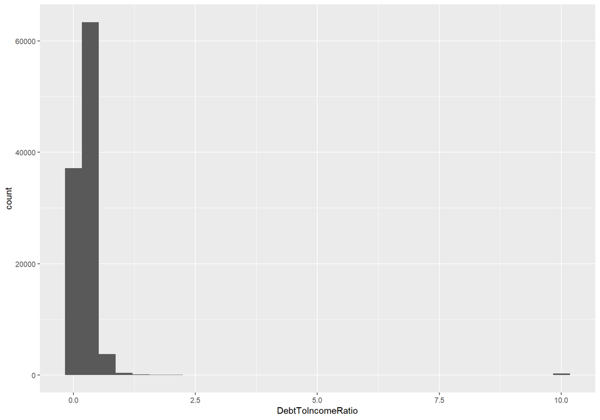

More than 75% of the listings have a debt to income ratio less than 0.32.

```
##    Min. 1st Qu.  Median    Mean 3rd Qu.    Max.    NA's
##   0.000   0.140   0.220   0.276   0.320  10.010    8554
```

#### Loan Amount

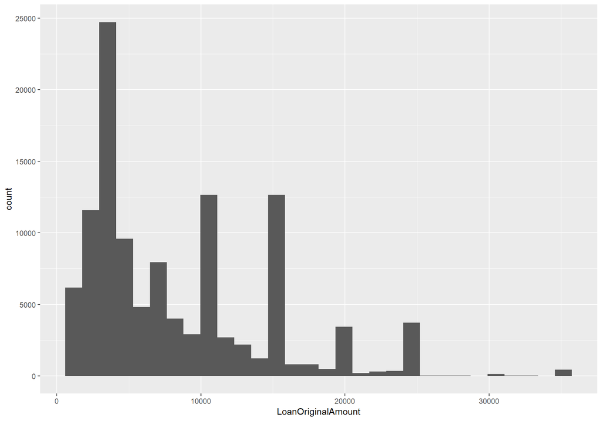

```
##    Min. 1st Qu.  Median    Mean 3rd Qu.    Max.
##    1000    4000    6500    8337   12000   35000
```

#### Investors

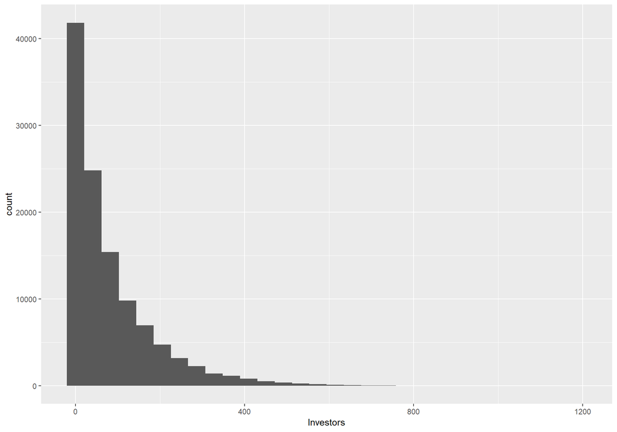

It is right skewed with a median of 44 and mean of 80.48.

```
##    Min. 1st Qu.  Median    Mean 3rd Qu.    Max.
##    1.00    2.00   44.00   80.48  115.00 1189.00
```

#### The Relationship between the Yield and Rating

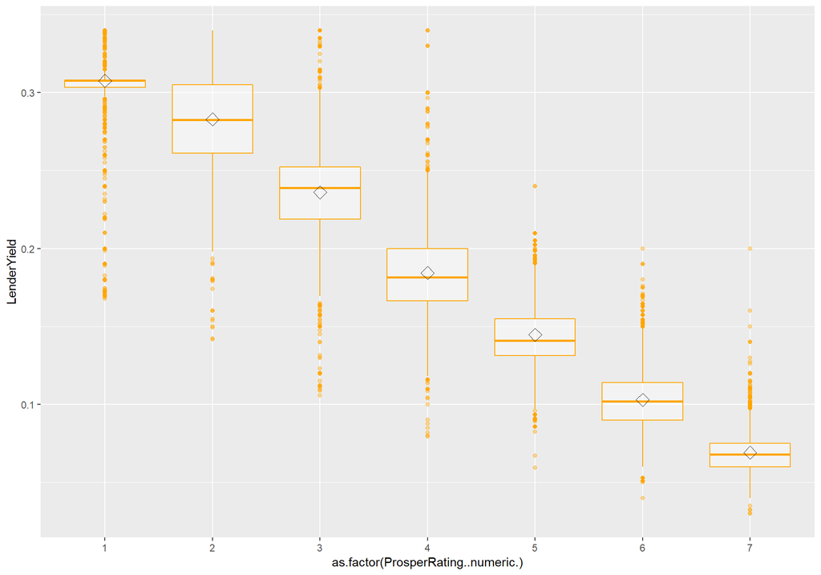

It can be noticed that the yield decreases when rating increases.

What is the trend when grouped by different loan status?

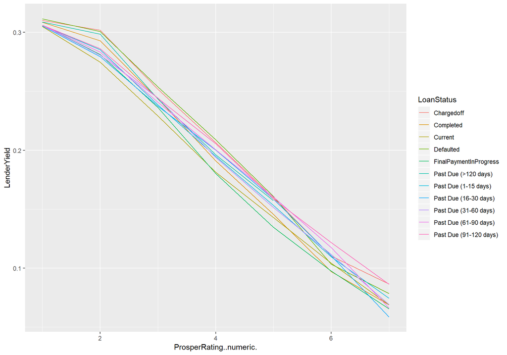

They all share the same trend, lender yield decreasing when prosper rating increasing.

#### Exploring the Relationship between Yield and Loan Amount

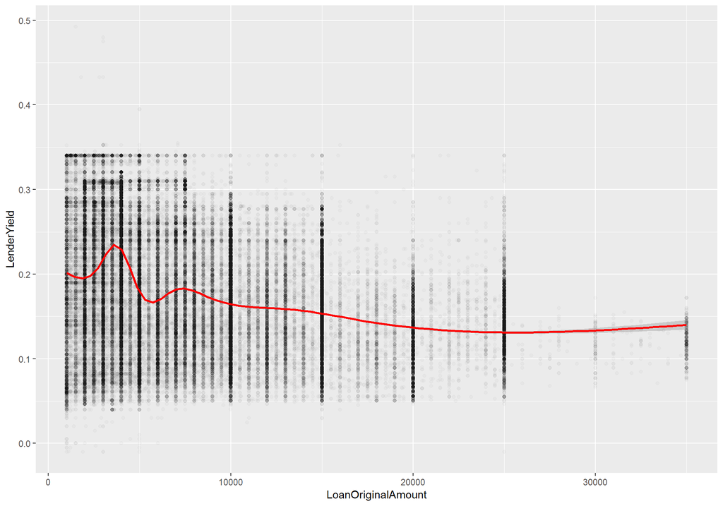

No clear pattern. It seems that there is no clear relationship between loan amount and lender yield. I supposed that the lender yield may increase when the loan amount increases.

#### The Relationship between Loan Amount and Rating.

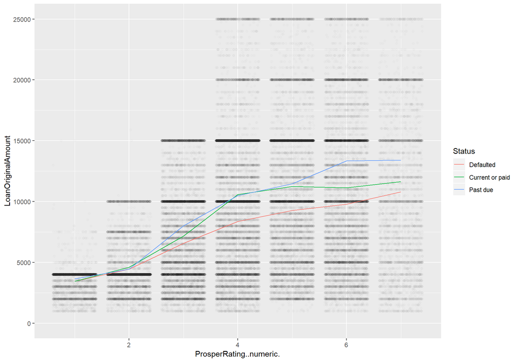

Listings with high risk tends to have low amount than that with low risk. It is probably that the borrowers with high risk know they cannot get a big loan. Defaulted loan has less loan amount on average than current or paid and past due loans.

#### Listing Category and Loan Amount

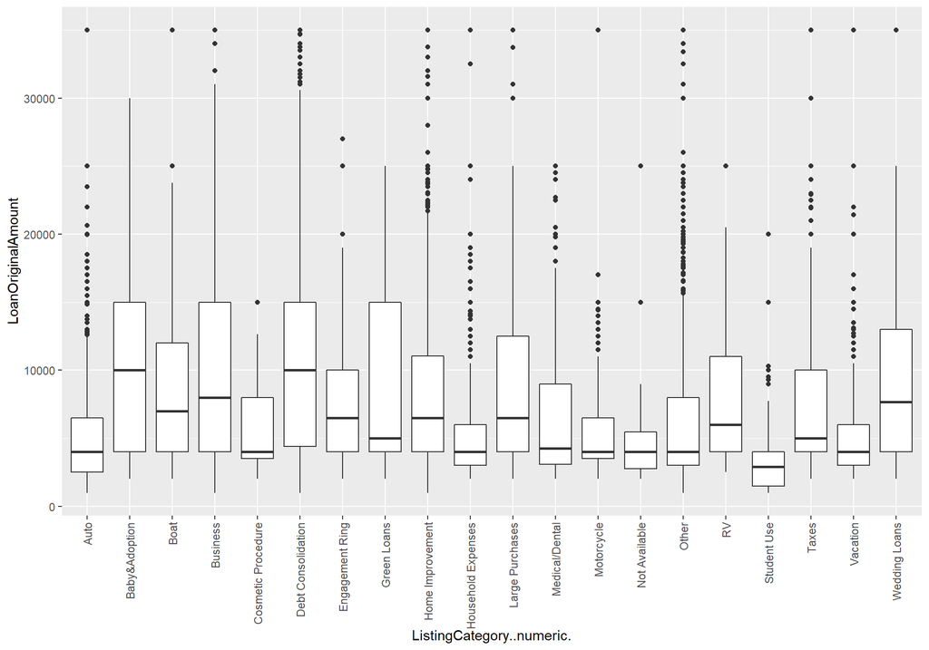

#### Loan Amount and Investors

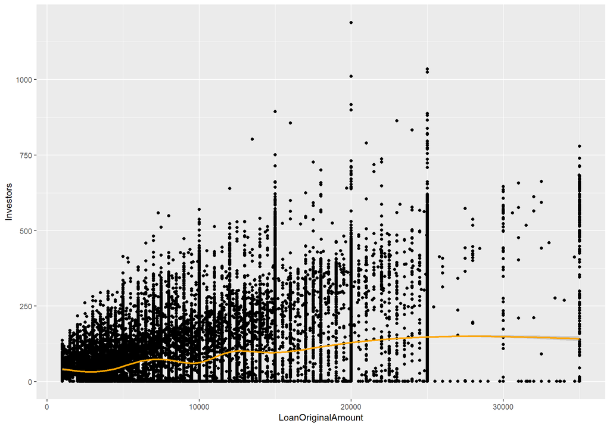

#### Lender Yield, Prosper Rate and Term

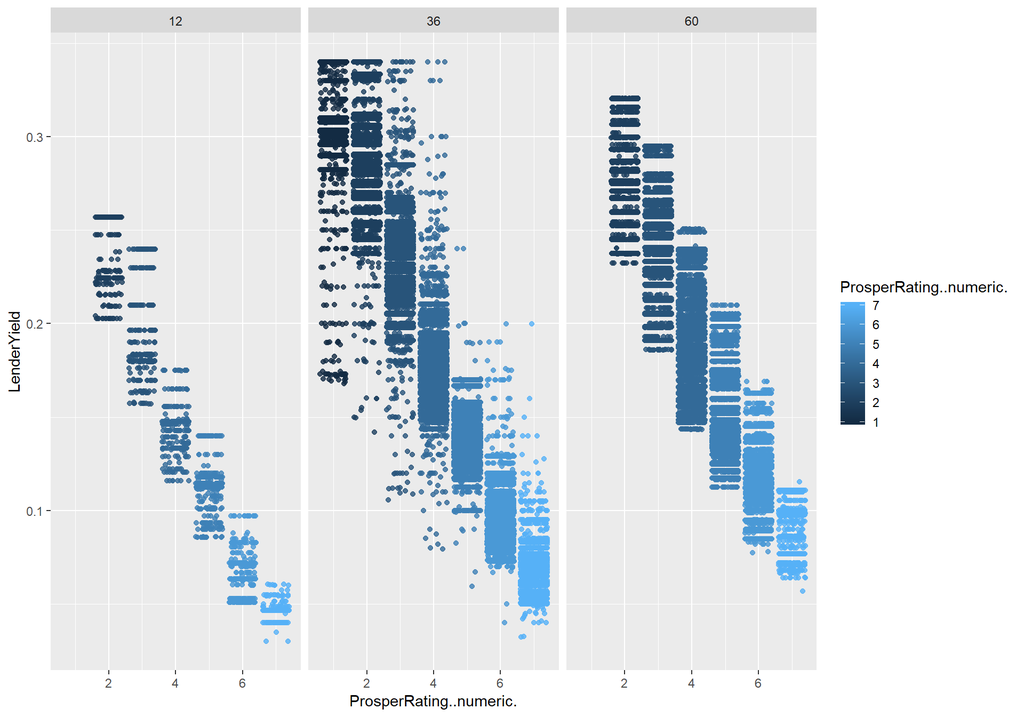

It can be noticed that the lender yield all exhibit the same trend in three term categories. Lender yield decreases when Prosper rating increases.

## Final Plots and Summary

### Plot 1

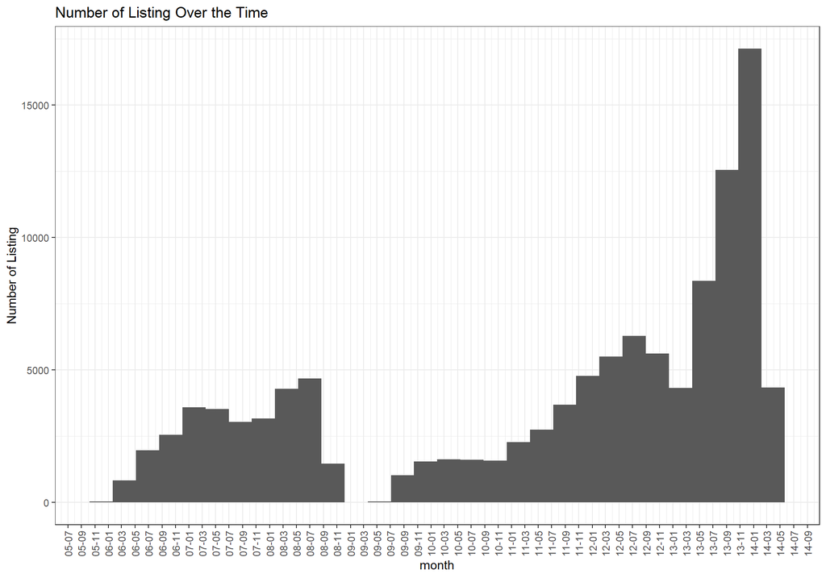

### Plot 2

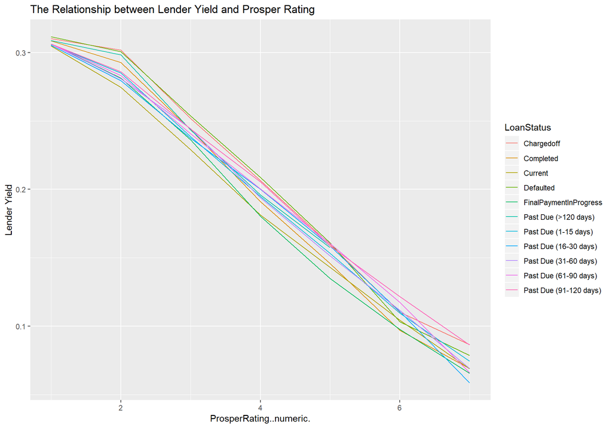

This is the plot of the relationship between lender yield and Propser rating. It indicates that, no matter what loan status, higher Prosper rating means lower lender yield. The average of lender yield is above 0.3 with rating of 1 and it decreases to around 0.1 with rating of 6.

### Plot 3

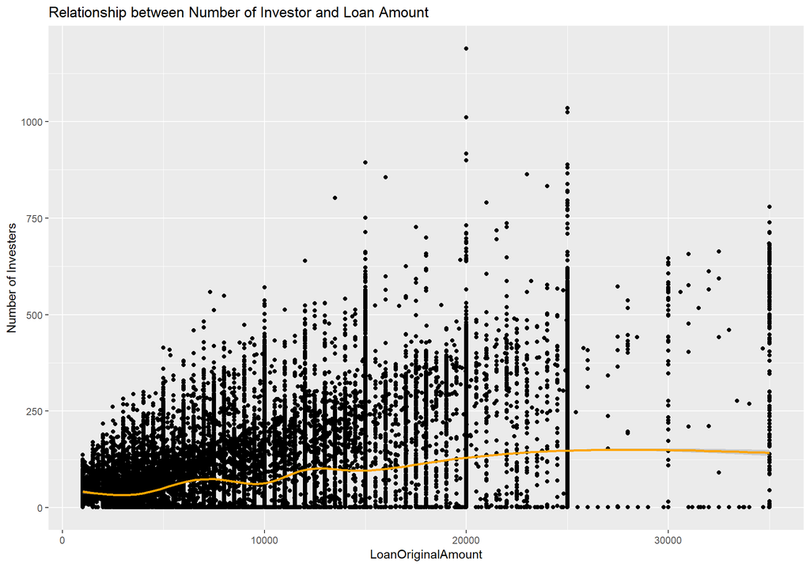

THis is the plot of the relationshop between number of investors and loan amount. I supposed that the larger loan amount, the more investors. The plot indicates that there is quite weak relationship between these two factors.

## Reflection

I spent a lot of time exploring the dataset to understanding the meaning of each variables. This dataset has 81 variables and I have to understanding all of them and then to choose the variables of interest for data analysis.

I got lost when exploring some of the variables at times. There are no obvious trend in some of the variable and I have to go back and forth to try the coorrelation between different variables.